# Características de los principales proveedores del hogar en Chile. Análisis en R.

Camilo Riquelme Horta

2022-07-02

[figure not shown]

##### Universidad Alberto Hurtado

##### Carrera: Sociología

##### Profesora: Valentina Andrade de la Horra

##### Ayudantes: Nicolás Godoy Marquéz y Dafne Jaime Vargas

##### Estudiante: Camilo Riquelme

## Abstract:

In this analysis I want to know the characteristics of the main household providers in Chile, through the information obtained from the ENE survey (march-may, 2022). This includes the average hours (daily and weekly) by region and by gender of the main providers, the number of days a week they work (gender and region), age group, occupational group, educational level and gender in which the providers are found.

## Resumen:

En el presente análisis quiero conocer las características de los/as principales proveedores del hogar en Chile, a través de la informacion obtenida de la encuesta ENE (marzo-mayo, 2022). Esto incluye el promedio de horas (diaria y semanal) por región y por sexo de los principales proveedores, cantidad de días a la semana que estos trabajan (sexo y region), tramo etario, grupo ocupacional, nivel educacional y sexo en que se encuentran los proveedores.

## Introducción:

A lo largo de nuestra vida hemos escuchado muchas características respecto a los/as proveedores del hogar, condiciones de lo que se consiedera un/a buen/a proveedor/a del hogar. En este caso realizaré un análisis de estas características con datos e información obtenidas en la Encuesta Nacional de Empleo (ENE), especificamente de marzo-abril-mayo del presente año 2022.

El análisis incluye el promedio de horas (diaria y semanal) por región y por sexo de los principales proveedores, cantidad de días a la semana que estos trabajan (sexo y region), tramo etario, grupo ocupacional, nivel educacional y sexo en que se encuentran los proveedores.

Es por eso que, con el fin de conocer las principales características, se codificaron/crearon las siguientes variables:

edad_tr: edad por tramos (jovenes: 18 a 29 años - Adultos: 30 a 59 años - Adultos Mayores: más de 60 años, según características de la población INE) cine: nivel educacional (codificado en educación básica, secundaria, técnica, universitaria y postitulos, maestría doctorado, según distintos reportes encuesta ESI y encuesta ENE) b1: grupo ocupacional según ciuo 08 sexo: sexo de la persona región: región en que vive la persona proveedor: sólo principal proveedor

Sumado a lo anterior se crearon nuevas variables a partir de c2_1_1 (horas diarias trabajadas), c2_1_2 (días a la semana trabajados) y c2_1_3 (horas semanales trabajadas), las cuales se agruparon en un promedio según sexo y región, creando las variables:

prom_hrs_drs_reg: promedio horas diarias de trabajo por region prom_hrs_sem_reg: promedio horas semanales de trabajo por region prom_dias_tr_reg: promedio dias de trabajo a la semana por region prom_hrs_drs_sexo: promedio horas diarias de trabajo por sexo prom_hrs_sem_sexo: promedio horas semanales de trabajo por sexo prom_dias_tr_sexo: promedio dias de trabajo a la semana por sexo

## Análisis:

## Gráficos: sexo, nivel educacional, grupo ocupacional, tramo etario y MTC edad de los principales proveedores del hogar en Chile.

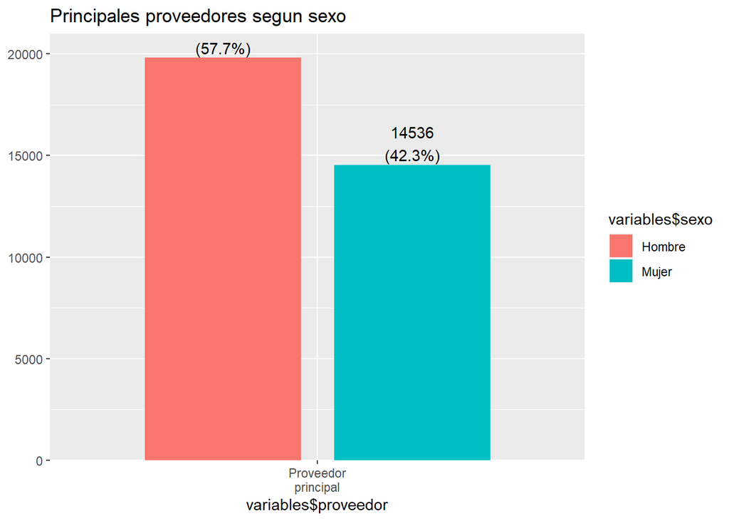

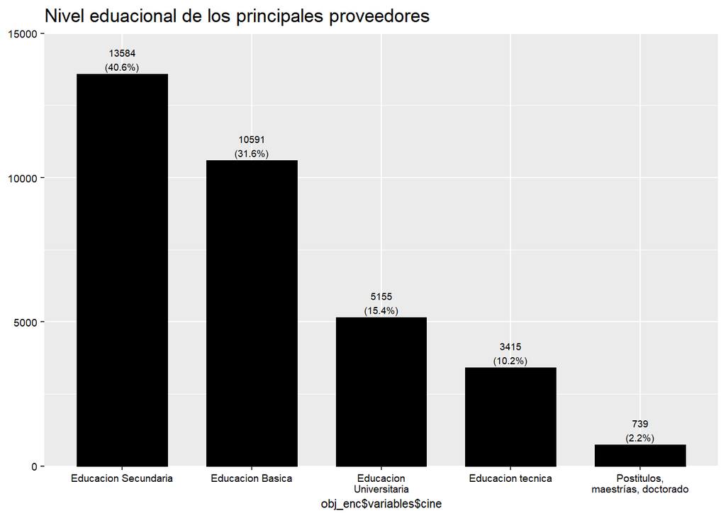

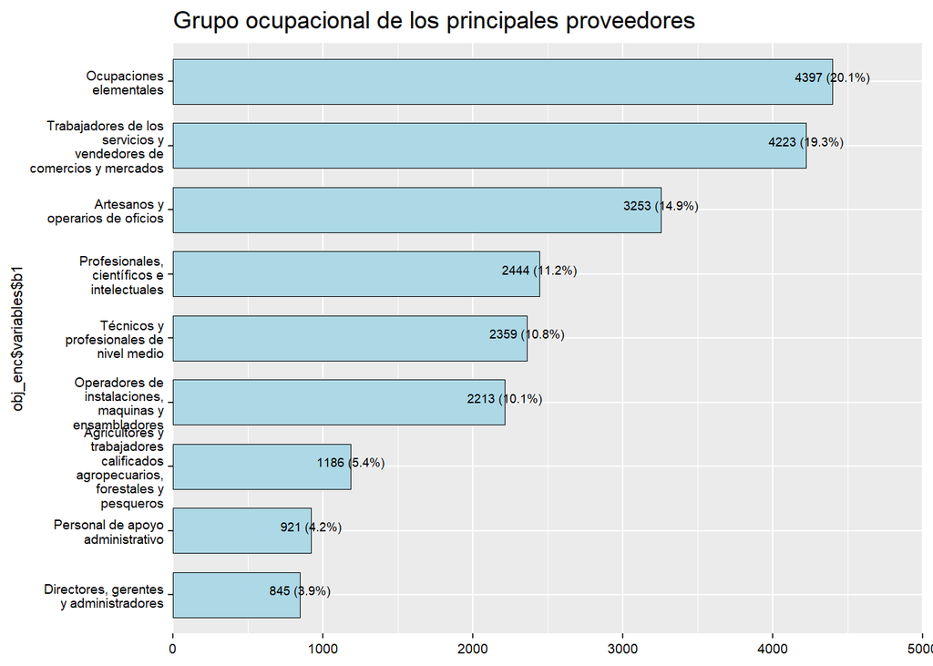

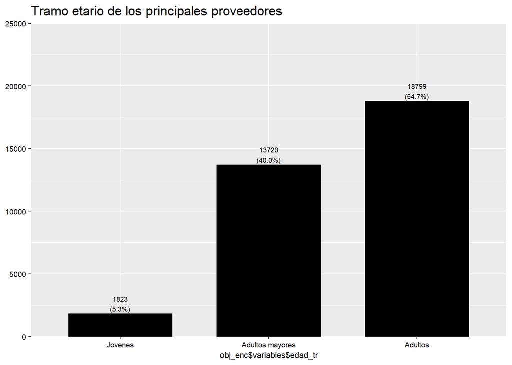

MTC Edad de los/as principales proveedores del hogar

| Variable | Etiqueta | n | Media | D. estandar | Mediana | Rango |
| --- | --- | --- | --- | --- | --- | --- |
| edad | Edad de la persona | 34342 | 54.85985 | 16.13404 | 55 | 84 (18-102) |

Fuente:  
Elaboración propia en base a ENE (2022)

## Tablas de promedio de horas (diarias - semanales) y promedio de días a la semana trabajados por los principales proveedores según región.

Promedio de horas diarias trabajadas por los principales proveedores segun region

| prom_hrs_drs_reg | region |  |  |  |  |  |  |  |  |  |  |  |  |  |  |  | Total |  |
| --- | --- | --- | --- | --- | --- | --- | --- | --- | --- | --- | --- | --- | --- | --- | --- | --- | --- | --- |
|  | Antofagasta | Arica y Parinacota | Atacama | Aysen | Biobio | Coquimbo | La Araucania | Los Lagos | Los Rios | Magallanes | Maule | Metropolitana | Ã‘uble | O’Higgins | Tarapaca | Valparaiso |  |  |
| 7.64784946236559 | 0 0 % 0 % | 0 0 % 0 % | 0 0 % 0 % | 825 100 % 100 % | 0 0 % 0 % | 0 0 % 0 % | 0 0 % 0 % | 0 0 % 0 % | 0 0 % 0 % | 0 0 % 0 % | 0 0 % 0 % | 0 0 % 0 % | 0 0 % 0 % | 0 0 % 0 % | 0 0 % 0 % | 0 0 % 0 % |  | 825 100 % 2.4 % |
| 7.6531713900135 | 0 0 % 0 % | 0 0 % 0 % | 0 0 % 0 % | 0 0 % 0 % | 0 0 % 0 % | 0 0 % 0 % | 1680 100 % 100 % | 0 0 % 0 % | 0 0 % 0 % | 0 0 % 0 % | 0 0 % 0 % | 0 0 % 0 % | 0 0 % 0 % | 0 0 % 0 % | 0 0 % 0 % | 0 0 % 0 % | 1680 100 % 4.9 % |  |
| 7.75810473815461 | 0 0 % 0 % | 1073 100 % 100 % | 0 0 % 0 % | 0 0 % 0 % | 0 0 % 0 % | 0 0 % 0 % | 0 0 % 0 % | 0 0 % 0 % | 0 0 % 0 % | 0 0 % 0 % | 0 0 % 0 % | 0 0 % 0 % | 0 0 % 0 % | 0 0 % 0 % | 0 0 % 0 % | 0 0 % 0 % | 1073 100 % 3.1 % |  |
| 7.78492239467849 | 0 0 % 0 % | 0 0 % 0 % | 1120 100 % 100 % | 0 0 % 0 % | 0 0 % 0 % | 0 0 % 0 % | 0 0 % 0 % | 0 0 % 0 % | 0 0 % 0 % | 0 0 % 0 % | 0 0 % 0 % | 0 0 % 0 % | 0 0 % 0 % | 0 0 % 0 % | 0 0 % 0 % | 0 0 % 0 % | 1120 100 % 3.3 % |  |
| 7.8109305760709 | 0 0 % 0 % | 0 0 % 0 % | 0 0 % 0 % | 0 0 % 0 % | 0 0 % 0 % | 0 0 % 0 % | 0 0 % 0 % | 0 0 % 0 % | 1648 100 % 100 % | 0 0 % 0 % | 0 0 % 0 % | 0 0 % 0 % | 0 0 % 0 % | 0 0 % 0 % | 0 0 % 0 % | 0 0 % 0 % | 1648 100 % 4.8 % |  |
| 7.86049723756906 | 0 0 % 0 % | 0 0 % 0 % | 0 0 % 0 % | 0 0 % 0 % | 0 0 % 0 % | 0 0 % 0 % | 0 0 % 0 % | 0 0 % 0 % | 0 0 % 0 % | 0 0 % 0 % | 0 0 % 0 % | 0 0 % 0 % | 1787 100 % 100 % | 0 0 % 0 % | 0 0 % 0 % | 0 0 % 0 % | 1787 100 % 5.2 % |  |
| 7.95277777777778 | 0 0 % 0 % | 0 0 % 0 % | 0 0 % 0 % | 0 0 % 0 % | 0 0 % 0 % | 0 0 % 0 % | 0 0 % 0 % | 0 0 % 0 % | 0 0 % 0 % | 870 100 % 100 % | 0 0 % 0 % | 0 0 % 0 % | 0 0 % 0 % | 0 0 % 0 % | 0 0 % 0 % | 0 0 % 0 % | 870 100 % 2.5 % |  |
| 7.97880928355197 | 0 0 % 0 % | 0 0 % 0 % | 0 0 % 0 % | 0 0 % 0 % | 0 0 % 0 % | 0 0 % 0 % | 0 0 % 0 % | 2646 100 % 100 % | 0 0 % 0 % | 0 0 % 0 % | 0 0 % 0 % | 0 0 % 0 % | 0 0 % 0 % | 0 0 % 0 % | 0 0 % 0 % | 0 0 % 0 % | 2646 100 % 7.7 % |  |
| 8.07857142857143 | 0 0 % 0 % | 0 0 % 0 % | 0 0 % 0 % | 0 0 % 0 % | 0 0 % 0 % | 0 0 % 0 % | 0 0 % 0 % | 0 0 % 0 % | 0 0 % 0 % | 0 0 % 0 % | 0 0 % 0 % | 0 0 % 0 % | 0 0 % 0 % | 0 0 % 0 % | 735 100 % 100 % | 0 0 % 0 % | 735 100 % 2.1 % |  |
| 8.12529550827423 | 0 0 % 0 % | 0 0 % 0 % | 0 0 % 0 % | 0 0 % 0 % | 0 0 % 0 % | 2147 100 % 100 % | 0 0 % 0 % | 0 0 % 0 % | 0 0 % 0 % | 0 0 % 0 % | 0 0 % 0 % | 0 0 % 0 % | 0 0 % 0 % | 0 0 % 0 % | 0 0 % 0 % | 0 0 % 0 % | 2147 100 % 6.3 % |  |
| 8.16480686695279 | 0 0 % 0 % | 0 0 % 0 % | 0 0 % 0 % | 0 0 % 0 % | 0 0 % 0 % | 0 0 % 0 % | 0 0 % 0 % | 0 0 % 0 % | 0 0 % 0 % | 0 0 % 0 % | 2729 100 % 100 % | 0 0 % 0 % | 0 0 % 0 % | 0 0 % 0 % | 0 0 % 0 % | 0 0 % 0 % | 2729 100 % 7.9 % |  |
| 8.17777777777778 | 1211 100 % 100 % | 0 0 % 0 % | 0 0 % 0 % | 0 0 % 0 % | 0 0 % 0 % | 0 0 % 0 % | 0 0 % 0 % | 0 0 % 0 % | 0 0 % 0 % | 0 0 % 0 % | 0 0 % 0 % | 0 0 % 0 % | 0 0 % 0 % | 0 0 % 0 % | 0 0 % 0 % | 0 0 % 0 % | 1211 100 % 3.5 % |  |
| 8.17836411609499 | 0 0 % 0 % | 0 0 % 0 % | 0 0 % 0 % | 0 0 % 0 % | 0 0 % 0 % | 0 0 % 0 % | 0 0 % 0 % | 0 0 % 0 % | 0 0 % 0 % | 0 0 % 0 % | 0 0 % 0 % | 0 0 % 0 % | 0 0 % 0 % | 0 0 % 0 % | 0 0 % 0 % | 3901 100 % 100 % | 3901 100 % 11.4 % |  |
| 8.21368547418968 | 0 0 % 0 % | 0 0 % 0 % | 0 0 % 0 % | 0 0 % 0 % | 4031 100 % 100 % | 0 0 % 0 % | 0 0 % 0 % | 0 0 % 0 % | 0 0 % 0 % | 0 0 % 0 % | 0 0 % 0 % | 0 0 % 0 % | 0 0 % 0 % | 0 0 % 0 % | 0 0 % 0 % | 0 0 % 0 % | 4031 100 % 11.7 % |  |
| 8.28142380422692 | 0 0 % 0 % | 0 0 % 0 % | 0 0 % 0 % | 0 0 % 0 % | 0 0 % 0 % | 0 0 % 0 % | 0 0 % 0 % | 0 0 % 0 % | 0 0 % 0 % | 0 0 % 0 % | 0 0 % 0 % | 0 0 % 0 % | 0 0 % 0 % | 2132 100 % 100 % | 0 0 % 0 % | 0 0 % 0 % | 2132 100 % 6.2 % |  |
| 8.28745198463508 | 0 0 % 0 % | 0 0 % 0 % | 0 0 % 0 % | 0 0 % 0 % | 0 0 % 0 % | 0 0 % 0 % | 0 0 % 0 % | 0 0 % 0 % | 0 0 % 0 % | 0 0 % 0 % | 0 0 % 0 % | 5807 100 % 100 % | 0 0 % 0 % | 0 0 % 0 % | 0 0 % 0 % | 0 0 % 0 % | 5807 100 % 16.9 % |  |
| Total | 1211 3.5 % 100 % | 1073 3.1 % 100 % | 1120 3.3 % 100 % | 825 2.4 % 100 % | 4031 11.7 % 100 % | 2147 6.3 % 100 % | 1680 4.9 % 100 % | 2646 7.7 % 100 % | 1648 4.8 % 100 % | 870 2.5 % 100 % | 2729 7.9 % 100 % | 5807 16.9 % 100 % | 1787 5.2 % 100 % | 2132 6.2 % 100 % | 735 2.1 % 100 % | 3901 11.4 % 100 % | 34342 100 % 100 % |  |

Promedio de horas semanales trabajadas por los principales proveedores segun region

| prom_hrs_sem_reg | region |  |  |  |  |  |  |  |  |  |  |  |  |  |  |  | Total |  |
| --- | --- | --- | --- | --- | --- | --- | --- | --- | --- | --- | --- | --- | --- | --- | --- | --- | --- | --- |
|  | Antofagasta | Arica y Parinacota | Atacama | Aysen | Biobio | Coquimbo | La Araucania | Los Lagos | Los Rios | Magallanes | Maule | Metropolitana | Ã‘uble | O’Higgins | Tarapaca | Valparaiso |  |  |
| 39.324777887463 | 0 0 % 0 % | 0 0 % 0 % | 0 0 % 0 % | 0 0 % 0 % | 0 0 % 0 % | 0 0 % 0 % | 1680 100 % 100 % | 0 0 % 0 % | 0 0 % 0 % | 0 0 % 0 % | 0 0 % 0 % | 0 0 % 0 % | 0 0 % 0 % | 0 0 % 0 % | 0 0 % 0 % | 0 0 % 0 % |  | 1680 100 % 4.9 % |
| 40.8178294573643 | 0 0 % 0 % | 0 0 % 0 % | 0 0 % 0 % | 0 0 % 0 % | 0 0 % 0 % | 0 0 % 0 % | 0 0 % 0 % | 0 0 % 0 % | 0 0 % 0 % | 0 0 % 0 % | 0 0 % 0 % | 0 0 % 0 % | 1787 100 % 100 % | 0 0 % 0 % | 0 0 % 0 % | 0 0 % 0 % | 1787 100 % 5.2 % |  |
| 40.9765840220386 | 0 0 % 0 % | 1073 100 % 100 % | 0 0 % 0 % | 0 0 % 0 % | 0 0 % 0 % | 0 0 % 0 % | 0 0 % 0 % | 0 0 % 0 % | 0 0 % 0 % | 0 0 % 0 % | 0 0 % 0 % | 0 0 % 0 % | 0 0 % 0 % | 0 0 % 0 % | 0 0 % 0 % | 0 0 % 0 % | 1073 100 % 3.1 % |  |
| 40.9987146529563 | 0 0 % 0 % | 0 0 % 0 % | 1120 100 % 100 % | 0 0 % 0 % | 0 0 % 0 % | 0 0 % 0 % | 0 0 % 0 % | 0 0 % 0 % | 0 0 % 0 % | 0 0 % 0 % | 0 0 % 0 % | 0 0 % 0 % | 0 0 % 0 % | 0 0 % 0 % | 0 0 % 0 % | 0 0 % 0 % | 1120 100 % 3.3 % |  |
| 41.0029821073559 | 0 0 % 0 % | 0 0 % 0 % | 0 0 % 0 % | 0 0 % 0 % | 0 0 % 0 % | 0 0 % 0 % | 0 0 % 0 % | 0 0 % 0 % | 1648 100 % 100 % | 0 0 % 0 % | 0 0 % 0 % | 0 0 % 0 % | 0 0 % 0 % | 0 0 % 0 % | 0 0 % 0 % | 0 0 % 0 % | 1648 100 % 4.8 % |  |
| 41.1514242878561 | 0 0 % 0 % | 0 0 % 0 % | 0 0 % 0 % | 825 100 % 100 % | 0 0 % 0 % | 0 0 % 0 % | 0 0 % 0 % | 0 0 % 0 % | 0 0 % 0 % | 0 0 % 0 % | 0 0 % 0 % | 0 0 % 0 % | 0 0 % 0 % | 0 0 % 0 % | 0 0 % 0 % | 0 0 % 0 % | 825 100 % 2.4 % |  |
| 41.1561353444762 | 0 0 % 0 % | 0 0 % 0 % | 0 0 % 0 % | 0 0 % 0 % | 0 0 % 0 % | 0 0 % 0 % | 0 0 % 0 % | 0 0 % 0 % | 0 0 % 0 % | 0 0 % 0 % | 0 0 % 0 % | 0 0 % 0 % | 0 0 % 0 % | 0 0 % 0 % | 0 0 % 0 % | 3901 100 % 100 % | 3901 100 % 11.4 % |  |
| 41.4520255863539 | 0 0 % 0 % | 0 0 % 0 % | 0 0 % 0 % | 0 0 % 0 % | 4031 100 % 100 % | 0 0 % 0 % | 0 0 % 0 % | 0 0 % 0 % | 0 0 % 0 % | 0 0 % 0 % | 0 0 % 0 % | 0 0 % 0 % | 0 0 % 0 % | 0 0 % 0 % | 0 0 % 0 % | 0 0 % 0 % | 4031 100 % 11.7 % |  |
| 41.4827586206897 | 0 0 % 0 % | 0 0 % 0 % | 0 0 % 0 % | 0 0 % 0 % | 0 0 % 0 % | 0 0 % 0 % | 0 0 % 0 % | 2646 100 % 100 % | 0 0 % 0 % | 0 0 % 0 % | 0 0 % 0 % | 0 0 % 0 % | 0 0 % 0 % | 0 0 % 0 % | 0 0 % 0 % | 0 0 % 0 % | 2646 100 % 7.7 % |  |
| 41.571320754717 | 0 0 % 0 % | 0 0 % 0 % | 0 0 % 0 % | 0 0 % 0 % | 0 0 % 0 % | 0 0 % 0 % | 0 0 % 0 % | 0 0 % 0 % | 0 0 % 0 % | 0 0 % 0 % | 0 0 % 0 % | 5807 100 % 100 % | 0 0 % 0 % | 0 0 % 0 % | 0 0 % 0 % | 0 0 % 0 % | 5807 100 % 16.9 % |  |
| 41.7010785824345 | 0 0 % 0 % | 0 0 % 0 % | 0 0 % 0 % | 0 0 % 0 % | 0 0 % 0 % | 2147 100 % 100 % | 0 0 % 0 % | 0 0 % 0 % | 0 0 % 0 % | 0 0 % 0 % | 0 0 % 0 % | 0 0 % 0 % | 0 0 % 0 % | 0 0 % 0 % | 0 0 % 0 % | 0 0 % 0 % | 2147 100 % 6.3 % |  |
| 42.0585846867749 | 0 0 % 0 % | 0 0 % 0 % | 0 0 % 0 % | 0 0 % 0 % | 0 0 % 0 % | 0 0 % 0 % | 0 0 % 0 % | 0 0 % 0 % | 0 0 % 0 % | 0 0 % 0 % | 2729 100 % 100 % | 0 0 % 0 % | 0 0 % 0 % | 0 0 % 0 % | 0 0 % 0 % | 0 0 % 0 % | 2729 100 % 7.9 % |  |
| 42.2047970479705 | 0 0 % 0 % | 0 0 % 0 % | 0 0 % 0 % | 0 0 % 0 % | 0 0 % 0 % | 0 0 % 0 % | 0 0 % 0 % | 0 0 % 0 % | 0 0 % 0 % | 0 0 % 0 % | 0 0 % 0 % | 0 0 % 0 % | 0 0 % 0 % | 0 0 % 0 % | 735 100 % 100 % | 0 0 % 0 % | 735 100 % 2.1 % |  |
| 42.414364640884 | 1211 100 % 100 % | 0 0 % 0 % | 0 0 % 0 % | 0 0 % 0 % | 0 0 % 0 % | 0 0 % 0 % | 0 0 % 0 % | 0 0 % 0 % | 0 0 % 0 % | 0 0 % 0 % | 0 0 % 0 % | 0 0 % 0 % | 0 0 % 0 % | 0 0 % 0 % | 0 0 % 0 % | 0 0 % 0 % | 1211 100 % 3.5 % |  |
| 42.6084905660377 | 0 0 % 0 % | 0 0 % 0 % | 0 0 % 0 % | 0 0 % 0 % | 0 0 % 0 % | 0 0 % 0 % | 0 0 % 0 % | 0 0 % 0 % | 0 0 % 0 % | 870 100 % 100 % | 0 0 % 0 % | 0 0 % 0 % | 0 0 % 0 % | 0 0 % 0 % | 0 0 % 0 % | 0 0 % 0 % | 870 100 % 2.5 % |  |
| 42.9213313161876 | 0 0 % 0 % | 0 0 % 0 % | 0 0 % 0 % | 0 0 % 0 % | 0 0 % 0 % | 0 0 % 0 % | 0 0 % 0 % | 0 0 % 0 % | 0 0 % 0 % | 0 0 % 0 % | 0 0 % 0 % | 0 0 % 0 % | 0 0 % 0 % | 2132 100 % 100 % | 0 0 % 0 % | 0 0 % 0 % | 2132 100 % 6.2 % |  |
| Total | 1211 3.5 % 100 % | 1073 3.1 % 100 % | 1120 3.3 % 100 % | 825 2.4 % 100 % | 4031 11.7 % 100 % | 2147 6.3 % 100 % | 1680 4.9 % 100 % | 2646 7.7 % 100 % | 1648 4.8 % 100 % | 870 2.5 % 100 % | 2729 7.9 % 100 % | 5807 16.9 % 100 % | 1787 5.2 % 100 % | 2132 6.2 % 100 % | 735 2.1 % 100 % | 3901 11.4 % 100 % | 34342 100 % 100 % |  |

Promedio de dÃas a la semana trabajados por los principales proveedores segun region

| prom_dias_tr_reg | region |  |  |  |  |  |  |  |  |  |  |  |  |  |  |  | Total |  |
| --- | --- | --- | --- | --- | --- | --- | --- | --- | --- | --- | --- | --- | --- | --- | --- | --- | --- | --- |
|  | Antofagasta | Arica y Parinacota | Atacama | Aysen | Biobio | Coquimbo | La Araucania | Los Lagos | Los Rios | Magallanes | Maule | Metropolitana | Ã‘uble | O’Higgins | Tarapaca | Valparaiso |  |  |
| 4.93553542887587 | 0 0 % 0 % | 0 0 % 0 % | 0 0 % 0 % | 0 0 % 0 % | 0 0 % 0 % | 0 0 % 0 % | 0 0 % 0 % | 0 0 % 0 % | 0 0 % 0 % | 0 0 % 0 % | 0 0 % 0 % | 5807 100 % 100 % | 0 0 % 0 % | 0 0 % 0 % | 0 0 % 0 % | 0 0 % 0 % |  | 5807 100 % 16.9 % |
| 4.93733451015004 | 0 0 % 0 % | 0 0 % 0 % | 0 0 % 0 % | 0 0 % 0 % | 0 0 % 0 % | 0 0 % 0 % | 0 0 % 0 % | 0 0 % 0 % | 0 0 % 0 % | 0 0 % 0 % | 0 0 % 0 % | 0 0 % 0 % | 0 0 % 0 % | 0 0 % 0 % | 0 0 % 0 % | 3901 100 % 100 % | 3901 100 % 11.4 % |  |
| 4.9801652892562 | 0 0 % 0 % | 0 0 % 0 % | 1120 100 % 100 % | 0 0 % 0 % | 0 0 % 0 % | 0 0 % 0 % | 0 0 % 0 % | 0 0 % 0 % | 0 0 % 0 % | 0 0 % 0 % | 0 0 % 0 % | 0 0 % 0 % | 0 0 % 0 % | 0 0 % 0 % | 0 0 % 0 % | 0 0 % 0 % | 1120 100 % 3.3 % |  |
| 5.00504032258065 | 0 0 % 0 % | 0 0 % 0 % | 0 0 % 0 % | 0 0 % 0 % | 0 0 % 0 % | 0 0 % 0 % | 1680 100 % 100 % | 0 0 % 0 % | 0 0 % 0 % | 0 0 % 0 % | 0 0 % 0 % | 0 0 % 0 % | 0 0 % 0 % | 0 0 % 0 % | 0 0 % 0 % | 0 0 % 0 % | 1680 100 % 4.9 % |  |
| 5.01559633027523 | 0 0 % 0 % | 0 0 % 0 % | 0 0 % 0 % | 0 0 % 0 % | 4031 100 % 100 % | 0 0 % 0 % | 0 0 % 0 % | 0 0 % 0 % | 0 0 % 0 % | 0 0 % 0 % | 0 0 % 0 % | 0 0 % 0 % | 0 0 % 0 % | 0 0 % 0 % | 0 0 % 0 % | 0 0 % 0 % | 4031 100 % 11.7 % |  |
| 5.04937163375224 | 0 0 % 0 % | 0 0 % 0 % | 0 0 % 0 % | 0 0 % 0 % | 0 0 % 0 % | 2147 100 % 100 % | 0 0 % 0 % | 0 0 % 0 % | 0 0 % 0 % | 0 0 % 0 % | 0 0 % 0 % | 0 0 % 0 % | 0 0 % 0 % | 0 0 % 0 % | 0 0 % 0 % | 0 0 % 0 % | 2147 100 % 6.3 % |  |
| 5.05583756345178 | 0 0 % 0 % | 0 0 % 0 % | 0 0 % 0 % | 0 0 % 0 % | 0 0 % 0 % | 0 0 % 0 % | 0 0 % 0 % | 0 0 % 0 % | 0 0 % 0 % | 0 0 % 0 % | 0 0 % 0 % | 0 0 % 0 % | 1787 100 % 100 % | 0 0 % 0 % | 0 0 % 0 % | 0 0 % 0 % | 1787 100 % 5.2 % |  |
| 5.06636500754148 | 1211 100 % 100 % | 0 0 % 0 % | 0 0 % 0 % | 0 0 % 0 % | 0 0 % 0 % | 0 0 % 0 % | 0 0 % 0 % | 0 0 % 0 % | 0 0 % 0 % | 0 0 % 0 % | 0 0 % 0 % | 0 0 % 0 % | 0 0 % 0 % | 0 0 % 0 % | 0 0 % 0 % | 0 0 % 0 % | 1211 100 % 3.5 % |  |
| 5.07453416149068 | 0 0 % 0 % | 1073 100 % 100 % | 0 0 % 0 % | 0 0 % 0 % | 0 0 % 0 % | 0 0 % 0 % | 0 0 % 0 % | 0 0 % 0 % | 0 0 % 0 % | 0 0 % 0 % | 0 0 % 0 % | 0 0 % 0 % | 0 0 % 0 % | 0 0 % 0 % | 0 0 % 0 % | 0 0 % 0 % | 1073 100 % 3.1 % |  |
| 5.15098468271335 | 0 0 % 0 % | 0 0 % 0 % | 0 0 % 0 % | 0 0 % 0 % | 0 0 % 0 % | 0 0 % 0 % | 0 0 % 0 % | 0 0 % 0 % | 0 0 % 0 % | 0 0 % 0 % | 0 0 % 0 % | 0 0 % 0 % | 0 0 % 0 % | 0 0 % 0 % | 735 100 % 100 % | 0 0 % 0 % | 735 100 % 2.1 % |  |
| 5.17341977309562 | 0 0 % 0 % | 0 0 % 0 % | 0 0 % 0 % | 825 100 % 100 % | 0 0 % 0 % | 0 0 % 0 % | 0 0 % 0 % | 0 0 % 0 % | 0 0 % 0 % | 0 0 % 0 % | 0 0 % 0 % | 0 0 % 0 % | 0 0 % 0 % | 0 0 % 0 % | 0 0 % 0 % | 0 0 % 0 % | 825 100 % 2.4 % |  |
| 5.1882140709561 | 0 0 % 0 % | 0 0 % 0 % | 0 0 % 0 % | 0 0 % 0 % | 0 0 % 0 % | 0 0 % 0 % | 0 0 % 0 % | 0 0 % 0 % | 0 0 % 0 % | 0 0 % 0 % | 2729 100 % 100 % | 0 0 % 0 % | 0 0 % 0 % | 0 0 % 0 % | 0 0 % 0 % | 0 0 % 0 % | 2729 100 % 7.9 % |  |
| 5.19753086419753 | 0 0 % 0 % | 0 0 % 0 % | 0 0 % 0 % | 0 0 % 0 % | 0 0 % 0 % | 0 0 % 0 % | 0 0 % 0 % | 0 0 % 0 % | 1648 100 % 100 % | 0 0 % 0 % | 0 0 % 0 % | 0 0 % 0 % | 0 0 % 0 % | 0 0 % 0 % | 0 0 % 0 % | 0 0 % 0 % | 1648 100 % 4.8 % |  |
| 5.21178120617111 | 0 0 % 0 % | 0 0 % 0 % | 0 0 % 0 % | 0 0 % 0 % | 0 0 % 0 % | 0 0 % 0 % | 0 0 % 0 % | 2646 100 % 100 % | 0 0 % 0 % | 0 0 % 0 % | 0 0 % 0 % | 0 0 % 0 % | 0 0 % 0 % | 0 0 % 0 % | 0 0 % 0 % | 0 0 % 0 % | 2646 100 % 7.7 % |  |
| 5.22377049180328 | 0 0 % 0 % | 0 0 % 0 % | 0 0 % 0 % | 0 0 % 0 % | 0 0 % 0 % | 0 0 % 0 % | 0 0 % 0 % | 0 0 % 0 % | 0 0 % 0 % | 0 0 % 0 % | 0 0 % 0 % | 0 0 % 0 % | 0 0 % 0 % | 2132 100 % 100 % | 0 0 % 0 % | 0 0 % 0 % | 2132 100 % 6.2 % |  |
| 5.27777777777778 | 0 0 % 0 % | 0 0 % 0 % | 0 0 % 0 % | 0 0 % 0 % | 0 0 % 0 % | 0 0 % 0 % | 0 0 % 0 % | 0 0 % 0 % | 0 0 % 0 % | 870 100 % 100 % | 0 0 % 0 % | 0 0 % 0 % | 0 0 % 0 % | 0 0 % 0 % | 0 0 % 0 % | 0 0 % 0 % | 870 100 % 2.5 % |  |
| Total | 1211 3.5 % 100 % | 1073 3.1 % 100 % | 1120 3.3 % 100 % | 825 2.4 % 100 % | 4031 11.7 % 100 % | 2147 6.3 % 100 % | 1680 4.9 % 100 % | 2646 7.7 % 100 % | 1648 4.8 % 100 % | 870 2.5 % 100 % | 2729 7.9 % 100 % | 5807 16.9 % 100 % | 1787 5.2 % 100 % | 2132 6.2 % 100 % | 735 2.1 % 100 % | 3901 11.4 % 100 % | 34342 100 % 100 % |  |

En las anteriores tablas según región, podemos observar que en promedio, hay menos de una hora diaria de diferencia entre la región que trabaja más (Metropolitana) con 8.29 horas diarias y un 16.9% de los casos y la región que trabaja menos (Aysén), con 7.65 horas diarias y un 2.4% de los casos. En cuanto a las horas semanales, obtenemos que hay más de 3 horas de diferencia entre la región que más horas a la semana trabaja (O’Higgins) con 42.92 horas a la semana, representando un 6.2% de los casos y la que menos horas trabaja (La Araucanía) con 39.32 horas a la semana, representando el 4.9% de los casos. Por último en cuanto a días a la semana trabajados por región, no alcanza a ser medio día de diferencia entre la que menos días a la semana trabaja (Metropolitana) con 4.94 días en promedio, representando el 16.9% de los casos y la que más días a la semana trabaja (Magallanes), con 5.28 días promedio a la semana y 2.5% de los casos.

## Tablas de promedio de horas (diarias - semanales) y promedio de días a la semana trabajados por los principales proveedores según sexo.

Promedio de horas diarias trabajadas por los principales proveedores segun sexo

| prom_hrs_drs_sexo | sexo |  | Total |  |
| --- | --- | --- | --- | --- |
|  | Hombre | Mujer |  |  |
| 7.62084724907717 | 0 0 % 0 % | 14536 100 % 100 % |  | 14536 100 % 42.3 % |
| 8.37357821141605 | 19806 100 % 100 % | 0 0 % 0 % | 19806 100 % 57.7 % |  |
| Total | 19806 57.7 % 100 % | 14536 42.3 % 100 % | 34342 100 % 100 % |  |

Promedio de horas semanales trabajadas por los principales proveedores segun sexo

| prom_hrs_sem_sexo | sexo |  | Total |  |
| --- | --- | --- | --- | --- |
|  | Hombre | Mujer |  |  |
| 38.6567480079681 | 0 0 % 0 % | 14536 100 % 100 % |  | 14536 100 % 42.3 % |
| 43.1366383652324 | 19806 100 % 100 % | 0 0 % 0 % | 19806 100 % 57.7 % |  |
| Total | 19806 57.7 % 100 % | 14536 42.3 % 100 % | 34342 100 % 100 % |  |

Promedio de días a la semana trabajados por los principales proveedores segun sexo

| prom_dias_tr_sexo | sexo |  | Total |  |
| --- | --- | --- | --- | --- |
|  | Hombre | Mujer |  |  |
| 4.86239604989605 | 0 0 % 0 % | 14536 100 % 100 % |  | 14536 100 % 42.3 % |
| 5.1866570327553 | 19806 100 % 100 % | 0 0 % 0 % | 19806 100 % 57.7 % |  |
| Total | 19806 57.7 % 100 % | 14536 42.3 % 100 % | 34342 100 % 100 % |  |

## Conclusión:

En conclusion, los principales proveedores del hogar, en cuanto a horas (diarias/semanales) y días de trabajo son bastante similares entre sí, las mayores diferencias las encontramos dentro de la variable de nivel educacional, donde el 72.2% de los casos se encuentra entre educación básica y media, y también la variable de edad donde el 94.7% de los casos son adultos y adultos mayores, es decir, la población entre mayor a los 30 años.

## Referencias:

*https://www.ine.cl/estadisticas/sociales/mercado-laboral/ocupacion-y-desocupacion*

*https://www.eluniverso.com/2011/07/01/1/1366/mucho-mas-proveedores-hogar.html/*

*https://www.informador.mx/economia/El-padre-principal-proveedor-economico-en-el-pais-20180616-0068.html*